# Econ 573: Problem Set 2 - Part 2

```r
Auto = read.csv("C:/Users/mateo/OneDrive - University of North Carolina at Chapel Hill/Courses/Spring 2025/Econ 573/Auto.csv")
```

*Question 8*

*(a) Use the lm() function to perform a simple linear regression with mpg as the response and horsepower as the predictor. Use the summary() function to print the results. Comment on the output.*

```r
Auto$horsepower <- as.numeric(as.character(Auto$horsepower)) #Convert the horspower variable form cetgorical to numeric
lmmpg = lm(mpg~horsepower, data = Auto) #Perform the simple linear regression
summary(lmmpg)
```

```
Call:
lm(formula = mpg ~ horsepower, data = Auto)

Residuals:
     Min       1Q   Median       3Q      Max
-13.5710  -3.2592  -0.3435   2.7630  16.9240

Coefficients:
             Estimate Std. Error t value Pr(>|t|)
(Intercept) 39.935861   0.717499   55.66   <2e-16 ***
horsepower  -0.157845   0.006446  -24.49   <2e-16 ***
---
Signif. codes:  0 ‘***’ 0.001 ‘**’ 0.01 ‘*’ 0.05 ‘.’ 0.1 ‘ ’ 1

Residual standard error: 4.906 on 390 degrees of freedom
  (5 observations deleted due to missingness)
Multiple R-squared:  0.6059,    Adjusted R-squared:  0.6049
F-statistic: 599.7 on 1 and 390 DF,  p-value: < 2.2e-16
```

There seems to be a small negative relationship between the amount of miles per gallon for a car and its horsepower. From its p-value, which is very close to $0$, we can infer strong evidence for this relationship such that it is statistically significant. The predicted coefficient for horsepower,$\beta_1 = -0.157845$, tells us that every one-unit increase in horsepower decreases mpg by -0.157845.

```r
horsepower98 = data.frame(horsepower = 98)
predict(lmmpg, horsepower98, interval = "confidence")
```

```
       fit      lwr      upr
1 24.46708 23.97308 24.96108
```

```r
predict(lmmpg, horsepower98, interval =  "prediction")
```

```
       fit     lwr      upr
1 24.46708 14.8094 34.12476
```

*Question 9*

*(a) Produce a scatterplot matrix which includes all of the variables in the data set.*

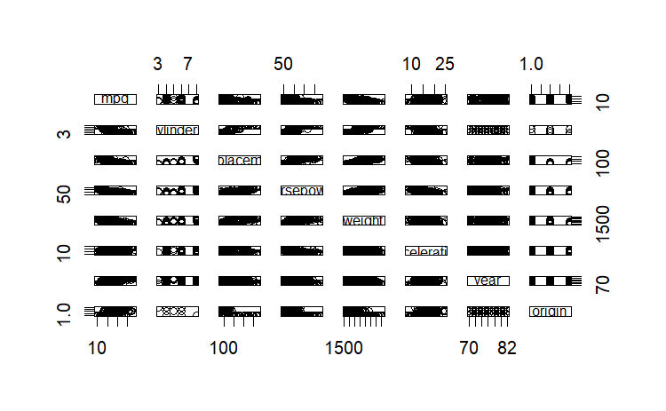

```r
pairs(Auto[, sapply(Auto, is.numeric)]) #Creates a scatterplot matrix for all the variables, selecting only numeric columns
```

*(b) Compute the matrix of correlations between the variables using the function cor(). You will need to exclude the name variable, cor() which is qualitative.*

```r
cor(Auto[, sapply(Auto, is.numeric)]) #Creats the matrix of correlations between variables, excluding the name variable
```

```
                    mpg  cylinders
mpg           1.0000000 -0.7762599
cylinders    -0.7762599  1.0000000
displacement -0.8044430  0.9509199
horsepower           NA         NA
weight       -0.8317389  0.8970169
acceleration  0.4222974 -0.5040606
year          0.5814695 -0.3467172
origin        0.5636979 -0.5649716
             displacement
mpg            -0.8044430
cylinders       0.9509199
displacement    1.0000000
horsepower             NA
weight          0.9331044
acceleration   -0.5441618
year           -0.3698041
origin         -0.6106643
             horsepower     weight
mpg                  NA -0.8317389
cylinders            NA  0.8970169
displacement         NA  0.9331044
horsepower            1         NA
weight               NA  1.0000000
acceleration         NA -0.4195023
year                 NA -0.3079004
origin               NA -0.5812652
             acceleration
mpg             0.4222974
cylinders      -0.5040606
displacement   -0.5441618
horsepower             NA
weight         -0.4195023
acceleration    1.0000000
year            0.2829009
origin          0.2100836
                   year     origin
mpg           0.5814695  0.5636979
cylinders    -0.3467172 -0.5649716
displacement -0.3698041 -0.6106643
horsepower           NA         NA
weight       -0.3079004 -0.5812652
acceleration  0.2829009  0.2100836
year          1.0000000  0.1843141
origin        0.1843141  1.0000000
```

*(c) Use the lm() function to perform a multiple linear regression with mpg as the response and all other variables except name as the predictors. Use the summary() function to print the results. Comment on the output.*

```r
mlmmpg = lm(mpg~cylinders + displacement + horsepower + weight + acceleration + year + origin, data = Auto)
summary(mlmmpg)
```

[output not shown]

The weight, year, and origin of the car appear to be the most statistically significant predictors, with p-values close to 0, indicating a strong relationship with mpg. The displacement predictor also seems statistically significant with a p-value close to 0.001. The remaining predictors have p-values closer to 1, suggesting they lack statistical significance in explaining variations in mpg.

The origin, year, and displacement predictors show a positive relationship with mpg. Specifically, origin has the strongest effect on mpg, with a coefficient of 1.4261 for one category relative to the baseline, followed by year with an effect of 0.7508 for each unit increase. Displacement has a smaller positive effect, with a coefficient of 0.0199 per unit increase. Conversely, weight exhibits a negative effect, reducing mpg by 0.0065 for every unit increase in weight.

*(d) Use the plot() function to produce diagnostic plots of the linear regression fit. Comment on any problems you see with the fit. Do the residual plots suggest any unusually large outliers? Does the leverage plot identify any observations with unusually high leverage?*

```r
par(mfrow = c(2,2)) #Set plot layout to 2x2 grid
plot(mlmmpg) #Generate plot
```

[output not shown]

The diagnostic plots reveal several insights about the model fit. The Q-Q plot shows that the residuals are approximately normally distributed, with minor deviations at the tails. The Residuals vs. Fitted plot suggests a slight non-linearity in the relationship between the predictors and mpg. The Scale-Location plot indicates mild heteroscedasticity, with residual variability increasing slightly as fitted values increase. Finally, the Residuals vs. Leverage plot does not highlight any high-leverage or overly influential observations, suggesting that no single data point disproportionately affects the model.

*(e) Use the* * *and : symbols to fit linear regression models with interaction effects. Do any interactions appear to be statistically significant?*

We can run a linear regression model incorporating interaction terms between the most statistically significant predictors to assess whether these interactions provide additional explanatory power for understanding the variability in miles per gallon (mpg).

```r
mpg_interac = lm(mpg~ cylinders + displacement + horsepower + weight + acceleration + year + origin + weight*year + weight*origin + weight*displacement + year*origin + year*displacement + origin* displacement + horsepower*year + horsepower*origin + horsepower*weight+ horsepower*displacement, data = Auto)
summary(mpg_interac)
```

[output not shown]

From the regression results, we observe that most interaction coefficients are not only small but also statistically insignificant. However, there are a few exceptions. With a p-value close to 0, the interaction terms weight:displacement and horsepower:year provide strong evidence of statistical significance, with an effect of 1.814e−5 and 6.93e-05, respectively, on mpg. The interaction terms horsepower:origin and displacement:origin also appear to be somewhat significant, with the former having a p-value close to 0.001 and the latter close to 0.01.

Additionally, we observe that the inclusion of interaction terms causes for the displacement, weight and origin predictors that were previously determined to be statistically significant to become insignificant. However, in the case of horsepower, strong evidence for its statistical significance was now found. This effect can be attributed to increased multicollinearity between the interaction terms and their associated individual predictors.

*(f) Try a few different transformations of the variables, such as log(X), √ X, X2. Comment on your findings.*

Logarithmic Transformation of Weight:

```r
log_lmmpg = lm(mpg ~ cylinders + displacement + horsepower + log(weight) + acceleration + year + origin, data = Auto)
summary(log_lmmpg)
```

[output not shown]

```r
par(mfrow = c(2,2))
plot(log_lmmpg)
```

[output not shown]

With the logarithmic transformation of the weight predictor, we don’t see any changes in the significance of the predictors. However, we do see an increase in the Adjusted R-squared compared to the original model (0.8431 > 0.8182)indicating a better fit. Residual plots exhibit virtually no changes compared to the original model.

Square Root Transformation of Acceleration and Horsepower:

```r
sqrt_lmmpg = lm(mpg ~ cylinders + displacement + sqrt(horsepower) + weight + sqrt(acceleration) + year + origin, data = Auto)
summary(sqrt_lmmpg)
```

[output not shown]

```r
par(mfrow = c(2,2))
plot(sqrt_lmmpg)
```

[output not shown]

With the square root transformation applied to acceleration and horsepower, we observe that the transformed horsepower predictor gained statistical significance. Additionally, the Adjusted R-squared value increased compared to the original model (0.8243 > 0.8182). However, residual plots remain virtually unchanged from those of the original model.

Quadratic Transformation of Horsepower and Weight:

```r
quad_lmmpg = lm(mpg ~ cylinders + displacement + I(horsepower^2) + I(weight^2) + acceleration + year + origin, data = Auto)
summary(quad_lmmpg)
```

[output not shown]

```r
par(mfrow = c(2,2))
plot(quad_lmmpg)
```

[output not shown]

When applying a quadratic transformation to horsepower and weight, the acceleration predictor lost its statistical significance. Furthermore, the transformed model exhibited a lower Adjusted R-squared value compared to the original model (0.7858 < 0.8182) suggesting a worse overall fit. Residual plots also show no noticeable differences from the original model.

*Question 13*

```r
set.seed(1)
```

*(a) Using the rnorm() function, create a vector, x, containing 100 observations drawn from a N(0, 1) distribution. This represents a feature, X.*

```r
x <- rnorm(100, mean = 0, sd = 1)
```

*(b) Using the rnorm() function, create a vector, eps, containing 100 observations drawn from a N(0, 0.25) distribution—a normal distribution with mean zero and variance 0.25.*

```r
eps = rnorm(100, mean = 0, sd = sqrt(0.25))
```

*(c) Using x and eps, generate a vector y according to the model Y = −1+0.5X + ϵ. (3.39) What is the length of the vector y? What are the values of β0 and β1 in this linear model?*

```r
y = -1 + 0.5*x + eps
```

The length of the vector will be 100, the same as both x and eps. The value of the intercept parameter is $\beta_0 = -1$, while the value of the slope parameter is $\beta_1 = 0.5$.

*(d) Create a scatterplot displaying the relationship between x and y. Comment on what you observe.*

```r
plot(x, y, main="Scatterplot of X vs Y", xlab="X", ylab="Y", pch=19, col="cadetblue1")
abline(-1, 0.5, col="black", lwd=2, lty=2)
```

[output not shown]

The scatterplot shows a positive, approximately linear relationship between X and Y. As X increases, Y tends to increase as well. However, the random noise introduced by the eps term creates some variability around the linear trend, resulting in a moderate spread of points across the regression line.

*(e) Fit a least squares linear model to predict y using x. Comment on the model obtained. How do βˆ0 and βˆ1 compare to β0 and β1?*

```r
lm = lm(y~x)
summary(lm)
```

```
Call:
lm(formula = y ~ x)

Residuals:
     Min       1Q   Median       3Q      Max
-1.45706 -0.24115 -0.02266  0.32462  1.32079

Coefficients:
            Estimate Std. Error t value Pr(>|t|)
(Intercept) -0.98632    0.05235 -18.840  < 2e-16
x            0.51058    0.05815   8.781 5.34e-14

(Intercept) ***
x           ***
---
Signif. codes:
0 ‘***’ 0.001 ‘**’ 0.01 ‘*’ 0.05 ‘.’ 0.1 ‘ ’ 1

Residual standard error: 0.5197 on 98 degrees of freedom
Multiple R-squared:  0.4403,    Adjusted R-squared:  0.4346
F-statistic:  77.1 on 1 and 98 DF,  p-value: 5.336e-14
```

The estimated intercept $\hat{\beta}_0 = -0.98632$ is close to the true value $\beta_0 = -1$. Similarly, the estimated coefficient for x $\hat{\beta}_1 = 0.51058$ is close to the true value $\beta_1 = 0.5$. The small deviation of these estimated values from the true values is due to the random noise introduced by the error term, ϵ. However, we can conclude that the model accurately captures the true relationship between x and y.

*Question 15*

```r
Boston <- read.csv("C:/Users/mateo/OneDrive - University of North Carolina at Chapel Hill/Courses/Spring 2025/Econ 573/ALL+CSV+FILES+-+2nd+Edition+-+corrected/ALL CSV FILES - 2nd Edition/Boston.csv", header = TRUE)
Boston <- Boston[, sapply(Boston, is.numeric)]
Boston <- Boston[, sapply(Boston, function(col) length(unique(col)) > 1)]
Boston <- Boston[, !names(Boston) %in% "X"]
Boston$chas <- as.factor(Boston$chas)
```

*(a) For each predictor, fit a simple linear regression model to predict the response. Describe your results. In which of the models is there a statistically significant association between the predictor and the response? Create some plots to back up your assertions.*

```r
model_zn = lm(crim ~ zn, data = Boston)
model_chas = lm(crim ~ chas, data = Boston)
model_indus = lm(crim ~ indus, data = Boston)
model_nox = lm(crim ~ nox, data = Boston)
model_rm = lm(crim ~ rm, data = Boston)
model_age = lm(crim ~ age, data = Boston)
model_dis = lm(crim ~ dis, data = Boston)
model_rad = lm(crim ~ rad, data = Boston)
model_tax = lm(crim ~ tax, data = Boston)
model_ptratio = lm(crim ~ ptratio, data = Boston)
model_lstat = lm(crim ~ lstat, data = Boston)
model_medv = lm(crim ~ medv, data = Boston)

summary(model_zn)
```

```
Call:
lm(formula = crim ~ zn, data = Boston)

Residuals:
   Min     1Q Median     3Q    Max
-4.429 -4.222 -2.620  1.250 84.523

Coefficients:
            Estimate Std. Error t value Pr(>|t|)
(Intercept)  4.45369    0.41722  10.675  < 2e-16 ***
zn          -0.07393    0.01609  -4.594 5.51e-06 ***
---
Signif. codes:  0 ‘***’ 0.001 ‘**’ 0.01 ‘*’ 0.05 ‘.’ 0.1 ‘ ’ 1

Residual standard error: 8.435 on 504 degrees of freedom
Multiple R-squared:  0.04019,   Adjusted R-squared:  0.03828
F-statistic:  21.1 on 1 and 504 DF,  p-value: 5.506e-06
```

```r
summary(model_chas)
```

```
Call:
lm(formula = crim ~ chas, data = Boston)

Residuals:
   Min     1Q Median     3Q    Max
-3.738 -3.661 -3.435  0.018 85.232

Coefficients:
            Estimate Std. Error t value Pr(>|t|)
(Intercept)   3.7444     0.3961   9.453   <2e-16 ***
chas1        -1.8928     1.5061  -1.257    0.209
---
Signif. codes:  0 ‘***’ 0.001 ‘**’ 0.01 ‘*’ 0.05 ‘.’ 0.1 ‘ ’ 1

Residual standard error: 8.597 on 504 degrees of freedom
Multiple R-squared:  0.003124,  Adjusted R-squared:  0.001146
F-statistic: 1.579 on 1 and 504 DF,  p-value: 0.2094
```

```r
summary(model_indus)
```

```
Call:
lm(formula = crim ~ indus, data = Boston)

Residuals:
    Min      1Q  Median      3Q     Max
-11.972  -2.698  -0.736   0.712  81.813

Coefficients:
            Estimate Std. Error t value Pr(>|t|)
(Intercept) -2.06374    0.66723  -3.093  0.00209 **
indus        0.50978    0.05102   9.991  < 2e-16 ***
---
Signif. codes:  0 ‘***’ 0.001 ‘**’ 0.01 ‘*’ 0.05 ‘.’ 0.1 ‘ ’ 1

Residual standard error: 7.866 on 504 degrees of freedom
Multiple R-squared:  0.1653,    Adjusted R-squared:  0.1637
F-statistic: 99.82 on 1 and 504 DF,  p-value: < 2.2e-16
```

```r
summary(model_nox)
```

```
Call:
lm(formula = crim ~ nox, data = Boston)

Residuals:
    Min      1Q  Median      3Q     Max
-12.371  -2.738  -0.974   0.559  81.728

Coefficients:
            Estimate Std. Error t value Pr(>|t|)
(Intercept)  -13.720      1.699  -8.073 5.08e-15 ***
nox           31.249      2.999  10.419  < 2e-16 ***
---
Signif. codes:  0 ‘***’ 0.001 ‘**’ 0.01 ‘*’ 0.05 ‘.’ 0.1 ‘ ’ 1

Residual standard error: 7.81 on 504 degrees of freedom
Multiple R-squared:  0.1772,    Adjusted R-squared:  0.1756
F-statistic: 108.6 on 1 and 504 DF,  p-value: < 2.2e-16
```

```r
summary(model_rm)
```

```
Call:
lm(formula = crim ~ rm, data = Boston)

Residuals:
   Min     1Q Median     3Q    Max
-6.604 -3.952 -2.654  0.989 87.197

Coefficients:
            Estimate Std. Error t value Pr(>|t|)
(Intercept)   20.482      3.365   6.088 2.27e-09 ***
rm            -2.684      0.532  -5.045 6.35e-07 ***
---
Signif. codes:  0 ‘***’ 0.001 ‘**’ 0.01 ‘*’ 0.05 ‘.’ 0.1 ‘ ’ 1

Residual standard error: 8.401 on 504 degrees of freedom
Multiple R-squared:  0.04807,   Adjusted R-squared:  0.04618
F-statistic: 25.45 on 1 and 504 DF,  p-value: 6.347e-07
```

```r
summary(model_age)
```

```
Call:
lm(formula = crim ~ age, data = Boston)

Residuals:
   Min     1Q Median     3Q    Max
-6.789 -4.257 -1.230  1.527 82.849

Coefficients:
            Estimate Std. Error t value Pr(>|t|)
(Intercept) -3.77791    0.94398  -4.002 7.22e-05 ***
age          0.10779    0.01274   8.463 2.85e-16 ***
---
Signif. codes:  0 ‘***’ 0.001 ‘**’ 0.01 ‘*’ 0.05 ‘.’ 0.1 ‘ ’ 1

Residual standard error: 8.057 on 504 degrees of freedom
Multiple R-squared:  0.1244,    Adjusted R-squared:  0.1227
F-statistic: 71.62 on 1 and 504 DF,  p-value: 2.855e-16
```

```r
summary(model_dis)
```

```
Call:
lm(formula = crim ~ dis, data = Boston)

Residuals:
   Min     1Q Median     3Q    Max
-6.708 -4.134 -1.527  1.516 81.674

Coefficients:
            Estimate Std. Error t value Pr(>|t|)
(Intercept)   9.4993     0.7304  13.006   <2e-16 ***
dis          -1.5509     0.1683  -9.213   <2e-16 ***
---
Signif. codes:  0 ‘***’ 0.001 ‘**’ 0.01 ‘*’ 0.05 ‘.’ 0.1 ‘ ’ 1

Residual standard error: 7.965 on 504 degrees of freedom
Multiple R-squared:  0.1441,    Adjusted R-squared:  0.1425
F-statistic: 84.89 on 1 and 504 DF,  p-value: < 2.2e-16
```

```r
summary(model_rad)
```

```
Call:
lm(formula = crim ~ rad, data = Boston)

Residuals:
    Min      1Q  Median      3Q     Max
-10.164  -1.381  -0.141   0.660  76.433

Coefficients:
            Estimate Std. Error t value Pr(>|t|)
(Intercept) -2.28716    0.44348  -5.157 3.61e-07 ***
rad          0.61791    0.03433  17.998  < 2e-16 ***
---
Signif. codes:  0 ‘***’ 0.001 ‘**’ 0.01 ‘*’ 0.05 ‘.’ 0.1 ‘ ’ 1

Residual standard error: 6.718 on 504 degrees of freedom
Multiple R-squared:  0.3913,    Adjusted R-squared:   0.39
F-statistic: 323.9 on 1 and 504 DF,  p-value: < 2.2e-16
```

```r
summary(model_tax)
```

```
Call:
lm(formula = crim ~ tax, data = Boston)

Residuals:
    Min      1Q  Median      3Q     Max
-12.513  -2.738  -0.194   1.065  77.696

Coefficients:
             Estimate Std. Error t value Pr(>|t|)
(Intercept) -8.528369   0.815809  -10.45   <2e-16 ***
tax          0.029742   0.001847   16.10   <2e-16 ***
---
Signif. codes:  0 ‘***’ 0.001 ‘**’ 0.01 ‘*’ 0.05 ‘.’ 0.1 ‘ ’ 1

Residual standard error: 6.997 on 504 degrees of freedom
Multiple R-squared:  0.3396,    Adjusted R-squared:  0.3383
F-statistic: 259.2 on 1 and 504 DF,  p-value: < 2.2e-16
```

```r
summary(model_ptratio)
```

```
Call:
lm(formula = crim ~ ptratio, data = Boston)

Residuals:
   Min     1Q Median     3Q    Max
-7.654 -3.985 -1.912  1.825 83.353

Coefficients:
            Estimate Std. Error t value Pr(>|t|)
(Intercept) -17.6469     3.1473  -5.607 3.40e-08 ***
ptratio       1.1520     0.1694   6.801 2.94e-11 ***
---
Signif. codes:  0 ‘***’ 0.001 ‘**’ 0.01 ‘*’ 0.05 ‘.’ 0.1 ‘ ’ 1

Residual standard error: 8.24 on 504 degrees of freedom
Multiple R-squared:  0.08407,   Adjusted R-squared:  0.08225
F-statistic: 46.26 on 1 and 504 DF,  p-value: 2.943e-11
```

```r
summary(model_lstat)
```

```
Call:
lm(formula = crim ~ lstat, data = Boston)

Residuals:
    Min      1Q  Median      3Q     Max
-13.925  -2.822  -0.664   1.079  82.862

Coefficients:
            Estimate Std. Error t value Pr(>|t|)
(Intercept) -3.33054    0.69376  -4.801 2.09e-06 ***
lstat        0.54880    0.04776  11.491  < 2e-16 ***
---
Signif. codes:  0 ‘***’ 0.001 ‘**’ 0.01 ‘*’ 0.05 ‘.’ 0.1 ‘ ’ 1

Residual standard error: 7.664 on 504 degrees of freedom
Multiple R-squared:  0.2076,    Adjusted R-squared:  0.206
F-statistic:   132 on 1 and 504 DF,  p-value: < 2.2e-16
```

```r
summary(model_medv)
```

```
Call:
lm(formula = crim ~ medv, data = Boston)

Residuals:
   Min     1Q Median     3Q    Max
-9.071 -4.022 -2.343  1.298 80.957

Coefficients:
            Estimate Std. Error t value Pr(>|t|)
(Intercept) 11.79654    0.93419   12.63   <2e-16 ***
medv        -0.36316    0.03839   -9.46   <2e-16 ***
---
Signif. codes:  0 ‘***’ 0.001 ‘**’ 0.01 ‘*’ 0.05 ‘.’ 0.1 ‘ ’ 1

Residual standard error: 7.934 on 504 degrees of freedom
Multiple R-squared:  0.1508,    Adjusted R-squared:  0.1491
F-statistic: 89.49 on 1 and 504 DF,  p-value: < 2.2e-16
```

```r
par(mfrow = c(3, 4))

plot(Boston$zn, Boston$crim, main = "zn vs crim", xlab = "zn", ylab = "Crime Rate")
abline(model_zn, col = "red", lwd = 2)
```

```r
plot(Boston$indus, Boston$crim, main = "indus vs crim", xlab = "indus", ylab = "Crime Rate")
abline(model_indus, col = "red", lwd = 2)
```

```r
plot(Boston$nox, Boston$crim, main = "nox vs crim", xlab = "nox", ylab = "Crime Rate")
abline(model_nox, col = "red", lwd = 2)
```

```r
plot(Boston$rm, Boston$crim, main = "rm vs crim", xlab = "rm", ylab = "Crime Rate")
abline(model_rm, col = "red", lwd = 2)
```

```r
plot(Boston$age, Boston$crim, main = "age vs crim", xlab = "age", ylab = "Crime Rate")
abline(model_age, col = "red", lwd = 2)
```

```r
plot(Boston$dis, Boston$crim, main = "dis vs crim", xlab = "dis", ylab = "Crime Rate")
abline(model_dis, col = "red", lwd = 2)
```

```r
plot(Boston$rad, Boston$crim, main = "rad vs crim", xlab = "rad", ylab = "Crime Rate")
abline(model_rad, col = "red", lwd = 2)
```

```r
plot(Boston$tax, Boston$crim, main = "tax vs crim", xlab = "tax", ylab = "Crime Rate")
abline(model_tax, col = "red", lwd = 2)
```

```r
plot(Boston$ptratio, Boston$crim, main = "ptratio vs crim", xlab = "ptratio", ylab = "Crime Rate")
abline(model_ptratio, col = "red", lwd = 2)
```

```r
plot(Boston$lstat, Boston$crim, main = "lstat vs crim", xlab = "lstat", ylab = "Crime Rate")
abline(model_lstat, col = "red", lwd = 2)
```

```r
plot(Boston$medv, Boston$crim, main = "medv vs crim", xlab = "medv", ylab = "Crime Rate")
abline(model_medv, col = "red", lwd = 2)
```

[figure not shown]

```r
par(mfrow = c(1, 1))
```

*(b) Fit a multiple regression model to predict the response using all of the predictors. Describe your results. For which predictors can we reject the null hypothesis H0 : βj = 0?*

```r
multi_model <- lm(crim ~ ., data = Boston)
summary(multi_model)
```

```
Call:
lm(formula = crim ~ ., data = Boston)

Residuals:
   Min     1Q Median     3Q    Max
-8.534 -2.248 -0.348  1.087 73.923

Coefficients:
              Estimate Std. Error t value
(Intercept) 13.7783938  7.0818258   1.946
zn           0.0457100  0.0187903   2.433
indus       -0.0583501  0.0836351  -0.698
chas1       -0.8253776  1.1833963  -0.697
nox         -9.9575865  5.2898242  -1.882
rm           0.6289107  0.6070924   1.036
age         -0.0008483  0.0179482  -0.047
dis         -1.0122467  0.2824676  -3.584
rad          0.6124653  0.0875358   6.997
tax         -0.0037756  0.0051723  -0.730
ptratio     -0.3040728  0.1863598  -1.632
lstat        0.1388006  0.0757213   1.833
medv        -0.2200564  0.0598240  -3.678
            Pr(>|t|)
(Intercept) 0.052271 .
zn          0.015344 *
indus       0.485709
chas1       0.485841
nox         0.060370 .
rm          0.300738
age         0.962323
dis         0.000373 ***
rad         8.59e-12 ***
tax         0.465757
ptratio     0.103393
lstat       0.067398 .
medv        0.000261 ***
---
Signif. codes:
0 ‘***’ 0.001 ‘**’ 0.01 ‘*’ 0.05 ‘.’ 0.1 ‘ ’ 1

Residual standard error: 6.46 on 493 degrees of freedom
Multiple R-squared:  0.4493,    Adjusted R-squared:  0.4359
F-statistic: 33.52 on 12 and 493 DF,  p-value: < 2.2e-16
```

*(c) How do your results from (a) compare to your results from (b)? Create a plot displaying the univariate regression coefficients from (a) on the x-axis, and the multiple regression coefficients from (b) on the y-axis. That is, each predictor is displayed as a single point in the plot. Its coefficient in a simple linear regression model is shown on the x-axis, and its coefficient estimate in the multiple linear regression model is shown on the y-axis.*

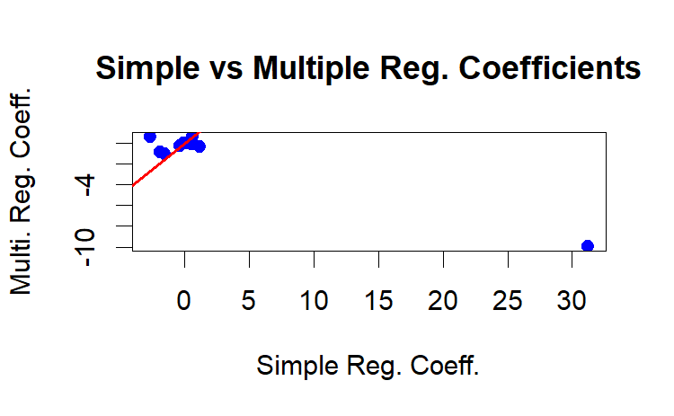

```r
simple_coefficients <- sapply(names(Boston)[-1], function(var) {
  model <- lm(as.formula(paste("crim ~", var)), data = Boston)  # Fit model
  coef(model)[2]  # Extract the coefficient (slope)
})
multi_coefficients <- coef(multi_model)[-1]
plot(simple_coefficients, multi_coefficients,
     xlab = "Simple Reg. Coeff.",
     ylab = "Multi. Reg. Coeff.",
     main = "Simple vs Multiple Reg. Coefficients",
     pch = 19, col = "blue")

abline(a = 0, b = 1, col = "red", lwd = 2)
```

```r
coefficient_differences <- simple_coefficients - multi_coefficients
sorted_differences <- sort(coefficient_differences, decreasing = TRUE)
print(sorted_differences)
```

```
        nox.nox ptratio.ptratio     indus.indus
   41.206117748     1.456055544     0.568126442
    lstat.lstat         age.age         tax.tax
    0.410004185     0.108634506     0.033517899
        rad.rad           zn.zn       medv.medv
    0.005445616    -0.119645016    -0.143103563
        dis.dis      chas.chas1           rm.rm
   -0.538654944    -1.067398999    -3.312961886
```

```r
largest_changes <- sort(abs(coefficient_differences), decreasing = TRUE)
print(largest_changes)
```

```
        nox.nox           rm.rm ptratio.ptratio
   41.206117748     3.312961886     1.456055544
     chas.chas1     indus.indus         dis.dis
    1.067398999     0.568126442     0.538654944
    lstat.lstat       medv.medv           zn.zn
    0.410004185     0.143103563     0.119645016
        age.age         tax.tax         rad.rad
    0.108634506     0.033517899     0.005445616
```

*(d) Is there evidence of non-linear association between any of the predictors and the response? To answer this question, for each predictor X, ft a model of the form Y = β0 + β1X + β2X2 + β3X3 + ϵ.*

```r
# Fit polynomial regression models for each predictor
model_zn <- lm(crim ~ poly(zn, 3), data = Boston)
model_indus <- lm(crim ~ poly(indus, 3), data = Boston)
model_nox <- lm(crim ~ poly(nox, 3), data = Boston)
model_rm <- lm(crim ~ poly(rm, 3), data = Boston)
model_age <- lm(crim ~ poly(age, 3), data = Boston)
model_dis <- lm(crim ~ poly(dis, 3), data = Boston)
model_rad <- lm(crim ~ poly(rad, 3), data = Boston)
model_tax <- lm(crim ~ poly(tax, 3), data = Boston)
model_ptratio <- lm(crim ~ poly(ptratio, 3), data = Boston)
model_lstat <- lm(crim ~ poly(lstat, 3), data = Boston)
model_medv <- lm(crim ~ poly(medv, 3), data = Boston)

summary(model_zn)
```

```
Call:
lm(formula = crim ~ poly(zn, 3), data = Boston)

Residuals:
   Min     1Q Median     3Q    Max
-4.821 -4.614 -1.294  0.473 84.130

Coefficients:
             Estimate Std. Error t value Pr(>|t|)
(Intercept)    3.6135     0.3722   9.709  < 2e-16
poly(zn, 3)1 -38.7498     8.3722  -4.628  4.7e-06
poly(zn, 3)2  23.9398     8.3722   2.859  0.00442
poly(zn, 3)3 -10.0719     8.3722  -1.203  0.22954

(Intercept)  ***
poly(zn, 3)1 ***
poly(zn, 3)2 **
poly(zn, 3)3
---
Signif. codes:
0 ‘***’ 0.001 ‘**’ 0.01 ‘*’ 0.05 ‘.’ 0.1 ‘ ’ 1

Residual standard error: 8.372 on 502 degrees of freedom
Multiple R-squared:  0.05824,   Adjusted R-squared:  0.05261
F-statistic: 10.35 on 3 and 502 DF,  p-value: 1.281e-06
```

```r
summary(model_indus)
```

```
Call:
lm(formula = crim ~ poly(indus, 3), data = Boston)

Residuals:
   Min     1Q Median     3Q    Max
-8.278 -2.514  0.054  0.764 79.713

Coefficients:
                Estimate Std. Error t value
(Intercept)        3.614      0.330  10.950
poly(indus, 3)1   78.591      7.423  10.587
poly(indus, 3)2  -24.395      7.423  -3.286
poly(indus, 3)3  -54.130      7.423  -7.292
                Pr(>|t|)
(Intercept)      < 2e-16 ***
poly(indus, 3)1  < 2e-16 ***
poly(indus, 3)2  0.00109 **
poly(indus, 3)3  1.2e-12 ***
---
Signif. codes:
0 ‘***’ 0.001 ‘**’ 0.01 ‘*’ 0.05 ‘.’ 0.1 ‘ ’ 1

Residual standard error: 7.423 on 502 degrees of freedom
Multiple R-squared:  0.2597,    Adjusted R-squared:  0.2552
F-statistic: 58.69 on 3 and 502 DF,  p-value: < 2.2e-16
```

```r
summary(model_nox)
```

```
Call:
lm(formula = crim ~ poly(nox, 3), data = Boston)

Residuals:
   Min     1Q Median     3Q    Max
-9.110 -2.068 -0.255  0.739 78.302

Coefficients:
              Estimate Std. Error t value
(Intercept)     3.6135     0.3216  11.237
poly(nox, 3)1  81.3720     7.2336  11.249
poly(nox, 3)2 -28.8286     7.2336  -3.985
poly(nox, 3)3 -60.3619     7.2336  -8.345
              Pr(>|t|)
(Intercept)    < 2e-16 ***
poly(nox, 3)1  < 2e-16 ***
poly(nox, 3)2 7.74e-05 ***
poly(nox, 3)3 6.96e-16 ***
---
Signif. codes:
0 ‘***’ 0.001 ‘**’ 0.01 ‘*’ 0.05 ‘.’ 0.1 ‘ ’ 1

Residual standard error: 7.234 on 502 degrees of freedom
Multiple R-squared:  0.297, Adjusted R-squared:  0.2928
F-statistic: 70.69 on 3 and 502 DF,  p-value: < 2.2e-16
```

```r
summary(model_rm)
```

```
Call:
lm(formula = crim ~ poly(rm, 3), data = Boston)

Residuals:
    Min      1Q  Median      3Q     Max
-18.485  -3.468  -2.221  -0.015  87.219

Coefficients:
             Estimate Std. Error t value Pr(>|t|)
(Intercept)    3.6135     0.3703   9.758  < 2e-16
poly(rm, 3)1 -42.3794     8.3297  -5.088 5.13e-07
poly(rm, 3)2  26.5768     8.3297   3.191  0.00151
poly(rm, 3)3  -5.5103     8.3297  -0.662  0.50858

(Intercept)  ***
poly(rm, 3)1 ***
poly(rm, 3)2 **
poly(rm, 3)3
---
Signif. codes:
0 ‘***’ 0.001 ‘**’ 0.01 ‘*’ 0.05 ‘.’ 0.1 ‘ ’ 1

Residual standard error: 8.33 on 502 degrees of freedom
Multiple R-squared:  0.06779,   Adjusted R-squared:  0.06222
F-statistic: 12.17 on 3 and 502 DF,  p-value: 1.067e-07
```

```r
summary(model_age)
```

```
Call:
lm(formula = crim ~ poly(age, 3), data = Boston)

Residuals:
   Min     1Q Median     3Q    Max
-9.762 -2.673 -0.516  0.019 82.842

Coefficients:
              Estimate Std. Error t value
(Intercept)     3.6135     0.3485  10.368
poly(age, 3)1  68.1820     7.8397   8.697
poly(age, 3)2  37.4845     7.8397   4.781
poly(age, 3)3  21.3532     7.8397   2.724
              Pr(>|t|)
(Intercept)    < 2e-16 ***
poly(age, 3)1  < 2e-16 ***
poly(age, 3)2 2.29e-06 ***
poly(age, 3)3  0.00668 **
---
Signif. codes:
0 ‘***’ 0.001 ‘**’ 0.01 ‘*’ 0.05 ‘.’ 0.1 ‘ ’ 1

Residual standard error: 7.84 on 502 degrees of freedom
Multiple R-squared:  0.1742,    Adjusted R-squared:  0.1693
F-statistic: 35.31 on 3 and 502 DF,  p-value: < 2.2e-16
```

```r
summary(model_dis)
```

```
Call:
lm(formula = crim ~ poly(dis, 3), data = Boston)

Residuals:
    Min      1Q  Median      3Q     Max
-10.757  -2.588   0.031   1.267  76.378

Coefficients:
              Estimate Std. Error t value
(Intercept)     3.6135     0.3259  11.087
poly(dis, 3)1 -73.3886     7.3315 -10.010
poly(dis, 3)2  56.3730     7.3315   7.689
poly(dis, 3)3 -42.6219     7.3315  -5.814
              Pr(>|t|)
(Intercept)    < 2e-16 ***
poly(dis, 3)1  < 2e-16 ***
poly(dis, 3)2 7.87e-14 ***
poly(dis, 3)3 1.09e-08 ***
---
Signif. codes:
0 ‘***’ 0.001 ‘**’ 0.01 ‘*’ 0.05 ‘.’ 0.1 ‘ ’ 1

Residual standard error: 7.331 on 502 degrees of freedom
Multiple R-squared:  0.2778,    Adjusted R-squared:  0.2735
F-statistic: 64.37 on 3 and 502 DF,  p-value: < 2.2e-16
```

```r
summary(model_rad)
```

```
Call:
lm(formula = crim ~ poly(rad, 3), data = Boston)

Residuals:
    Min      1Q  Median      3Q     Max
-10.381  -0.412  -0.269   0.179  76.217

Coefficients:
              Estimate Std. Error t value
(Intercept)     3.6135     0.2971  12.164
poly(rad, 3)1 120.9074     6.6824  18.093
poly(rad, 3)2  17.4923     6.6824   2.618
poly(rad, 3)3   4.6985     6.6824   0.703
              Pr(>|t|)
(Intercept)    < 2e-16 ***
poly(rad, 3)1  < 2e-16 ***
poly(rad, 3)2  0.00912 **
poly(rad, 3)3  0.48231
---
Signif. codes:
0 ‘***’ 0.001 ‘**’ 0.01 ‘*’ 0.05 ‘.’ 0.1 ‘ ’ 1

Residual standard error: 6.682 on 502 degrees of freedom
Multiple R-squared:    0.4, Adjusted R-squared:  0.3965
F-statistic: 111.6 on 3 and 502 DF,  p-value: < 2.2e-16
```

```r
summary(model_tax)
```

```
Call:
lm(formula = crim ~ poly(tax, 3), data = Boston)

Residuals:
    Min      1Q  Median      3Q     Max
-13.273  -1.389   0.046   0.536  76.950

Coefficients:
              Estimate Std. Error t value
(Intercept)     3.6135     0.3047  11.860
poly(tax, 3)1 112.6458     6.8537  16.436
poly(tax, 3)2  32.0873     6.8537   4.682
poly(tax, 3)3  -7.9968     6.8537  -1.167
              Pr(>|t|)
(Intercept)    < 2e-16 ***
poly(tax, 3)1  < 2e-16 ***
poly(tax, 3)2 3.67e-06 ***
poly(tax, 3)3    0.244
---
Signif. codes:
0 ‘***’ 0.001 ‘**’ 0.01 ‘*’ 0.05 ‘.’ 0.1 ‘ ’ 1

Residual standard error: 6.854 on 502 degrees of freedom
Multiple R-squared:  0.3689,    Adjusted R-squared:  0.3651
F-statistic:  97.8 on 3 and 502 DF,  p-value: < 2.2e-16
```

```r
summary(model_ptratio)
```

```
Call:
lm(formula = crim ~ poly(ptratio, 3), data = Boston)

Residuals:
   Min     1Q Median     3Q    Max
-6.833 -4.146 -1.655  1.408 82.697

Coefficients:
                  Estimate Std. Error t value
(Intercept)          3.614      0.361  10.008
poly(ptratio, 3)1   56.045      8.122   6.901
poly(ptratio, 3)2   24.775      8.122   3.050
poly(ptratio, 3)3  -22.280      8.122  -2.743
                  Pr(>|t|)
(Intercept)        < 2e-16 ***
poly(ptratio, 3)1 1.57e-11 ***
poly(ptratio, 3)2  0.00241 **
poly(ptratio, 3)3  0.00630 **
---
Signif. codes:
0 ‘***’ 0.001 ‘**’ 0.01 ‘*’ 0.05 ‘.’ 0.1 ‘ ’ 1

Residual standard error: 8.122 on 502 degrees of freedom
Multiple R-squared:  0.1138,    Adjusted R-squared:  0.1085
F-statistic: 21.48 on 3 and 502 DF,  p-value: 4.171e-13
```

```r
summary(model_lstat)
```

```
Call:
lm(formula = crim ~ poly(lstat, 3), data = Boston)

Residuals:
    Min      1Q  Median      3Q     Max
-15.234  -2.151  -0.486   0.066  83.353

Coefficients:
                Estimate Std. Error t value
(Intercept)       3.6135     0.3392  10.654
poly(lstat, 3)1  88.0697     7.6294  11.543
poly(lstat, 3)2  15.8882     7.6294   2.082
poly(lstat, 3)3 -11.5740     7.6294  -1.517
                Pr(>|t|)
(Intercept)       <2e-16 ***
poly(lstat, 3)1   <2e-16 ***
poly(lstat, 3)2   0.0378 *
poly(lstat, 3)3   0.1299
---
Signif. codes:
0 ‘***’ 0.001 ‘**’ 0.01 ‘*’ 0.05 ‘.’ 0.1 ‘ ’ 1

Residual standard error: 7.629 on 502 degrees of freedom
Multiple R-squared:  0.2179,    Adjusted R-squared:  0.2133
F-statistic: 46.63 on 3 and 502 DF,  p-value: < 2.2e-16
```

```r
summary(model_medv)
```

```
Call:
lm(formula = crim ~ poly(medv, 3), data = Boston)

Residuals:
    Min      1Q  Median      3Q     Max
-24.427  -1.976  -0.437   0.439  73.655

Coefficients:
               Estimate Std. Error t value
(Intercept)       3.614      0.292  12.374
poly(medv, 3)1  -75.058      6.569 -11.426
poly(medv, 3)2   88.086      6.569  13.409
poly(medv, 3)3  -48.033      6.569  -7.312
               Pr(>|t|)
(Intercept)     < 2e-16 ***
poly(medv, 3)1  < 2e-16 ***
poly(medv, 3)2  < 2e-16 ***
poly(medv, 3)3 1.05e-12 ***
---
Signif. codes:
0 ‘***’ 0.001 ‘**’ 0.01 ‘*’ 0.05 ‘.’ 0.1 ‘ ’ 1

Residual standard error: 6.569 on 502 degrees of freedom
Multiple R-squared:  0.4202,    Adjusted R-squared:  0.4167
F-statistic: 121.3 on 3 and 502 DF,  p-value: < 2.2e-16
```

The results reveal strong evidence of non-linear relationships between several predictors and crime rate (crim). Notably, nox (nitric oxide concentration), dis (distance to employment centers), and medv (median home value) exhibit highly significant quadratic and cubic terms, with p-values close to 0. This indicates complex non-linear associations that impact crime rate. Predictors like indus (non-retail business acres), age (proportion of older housing), and ptratio (pupil-teacher ratio) show moderate non-linear effects with significant quadratic and cubic terms with their p-values being less than 0.01